# Variable coding for the BPA/BPS vs birth weight

Since last time:

- Replace tobacco by ariane’s vars
- Add all betas (all model outputs actually)
- for gestational age compare (age + age²) and (age² + age³)
- Compare Height + Weight and BMI
- Compare weight and 2 slopes with cutoff at 60kg

To discuss:

- which REF for gestational age as polynomial (add to this doc)
- choose smoke variable, changed since inclusion of new smoke vars (ariane) and new coding (age + age2 & height + weight)
- choose mom education (two with same AIC)
- confirm weight + height VS BMI
- which confusion factors were not available? (paternal characteristics, food habits…)

# 1 Intro

In this document we justify the selection of the variables in the **growth ouctomes vs BPA/BPS** analysis model and their coding. We will focus on birth weight as an outcome and extend the conclusions from this report to other outcomes.

We provide a special focus on the variables measuring tobacco consumption.

# 2 DAG

Hence the final selection of adjutment factors:

- BPA_t1
- BPA_t3
- mom age at delivery
- smoking
- maternal education
- child sex
- parity
- pre pregnancy bmi/mom height + weight
- gestational age at delivery

* occupation included in sensitivity analyses only

# 3 Descriptive

In this section we provide a brief descriptive of each potential variable to be included in the model excluding exposure and tobacco.

Numeric vars (continued below)

| mom_age | mom_height | mom_weight | mom_bmi |
| --- | --- | --- | --- |
| Min. :20.56 | Min. :150.0 | Min. : 41.0 | Min. :16.97 |
| 1st Qu.:29.91 | 1st Qu.:160.8 | 1st Qu.: 53.5 | 1st Qu.:19.72 |
| Median :32.19 | Median :164.5 | Median : 59.0 | Median :21.53 |
| Mean :32.52 | Mean :165.1 | Mean : 61.0 | Mean :22.39 |
| 3rd Qu.:35.16 | 3rd Qu.:169.2 | 3rd Qu.: 66.0 | 3rd Qu.:24.02 |
| Max. :45.47 | Max. :187.0 | Max. :117.0 | Max. :41.95 |
| NA | NA’s :4 | NA | NA’s :4 |

| gestational_age_weeks |
| --- |
| Min. :30.71 |
| 1st Qu.:39.00 |
| Median :40.00 |
| Mean :39.75 |
| 3rd Qu.:40.71 |
| Max. :43.43 |
| NA |

Factors

| child_sex | parity | mom_edu_raw |
| --- | --- | --- |
| 1:245 | 0:206 | : 3 |
| 2:212 | 1:203 | 3: 5 |
|  | 2: 48 | 4: 10 |
|  |  | 5: 11 |
|  |  | 6: 52 |
|  |  | 7:119 |
|  |  | 8:257 |

# 4 Smoke data

Here we provide a brief descriptive of all the available smoking variables.

**Definition**: Smoke high means >= 1 cig/day

pre-pregnancy

| smoke_pre_detection |
| --- |
| Min. : 0.000 |
| 1st Qu.: 0.000 |
| Median : 0.000 |
| Mean : 0.462 |
| 3rd Qu.: 0.000 |
| Max. :15.000 |
| NA’s :38 |

First trimester

| smoke_n_cig_t1 | smoke_t1 | smoke_high_t1 | smoke_high_t1_t2 |
| --- | --- | --- | --- |
| Min. :0.0000 | 0 :401 | 0 :407 | 0 :404 |
| 1st Qu.:0.0000 | 1 : 21 | 1 : 14 | 1 : 14 |
| Median :0.0000 | NA’s: 35 | NA’s: 36 | NA’s: 39 |
| Mean :0.1211 |  |  |  |
| 3rd Qu.:0.0000 |  |  |  |
| Max. :9.2857 |  |  |  |
| NA’s :36 |  |  |  |

Second trimester

| smoke_n_cig_t2 | smoke_t2 | smoke_high_t2 | smoke_high_t1_t2 |
| --- | --- | --- | --- |
| Min. :0.00000 | 0 :406 | 0 :414 | 0 :404 |
| 1st Qu.:0.00000 | 1 : 21 | 1 : 10 | 1 : 14 |
| Median :0.00000 | NA’s: 30 | NA’s: 33 | NA’s: 39 |
| Mean :0.06671 |  |  |  |
| 3rd Qu.:0.00000 |  |  |  |
| Max. :7.14286 |  |  |  |
| NA’s :33 |  |  |  |

Third trimester

| smoke_n_cig_t3 | smoke_t3 | smoke_high_t3 |
| --- | --- | --- |
| Min. :0.0000 | 0 :413 | 0 :397 |
| 1st Qu.:0.0000 | 1 : 7 | 1 : 6 |
| Median :0.0000 | NA’s: 37 | NA’s: 54 |
| Mean :0.0436 |  |  |
| 3rd Qu.:0.0000 |  |  |
| Max. :7.0000 |  |  |
| NA’s :54 |  |  |

Any time during pregnancy

| smoke_any | smoke_any_high |
| --- | --- |
| 0 :398 | 0 :385 |
| 1 : 27 | 1 : 17 |
| NA’s: 32 | NA’s: 55 |

# 5 Variable coding

Quick reminder: *Given a set of candidate models for the data, the preferred model is the one with the* **minimum AIC value**

AIC computed using model presented in intro without exposure

## 5.1 Continuous variables

### 5.1.1 Mom age at delivery

- Continuous

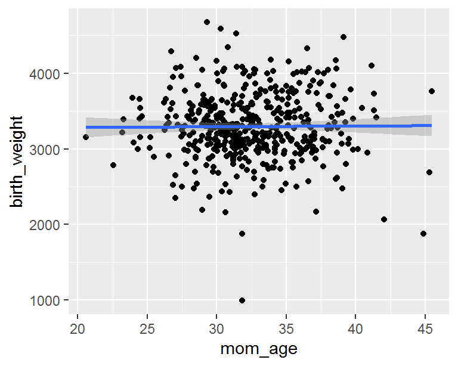

```
##
## Call:
## lm(formula = birth_weight ~ mom_age + mom_edu_length + child_sex +
##     parity_cat + mom_weight + mom_height + gestational_age_weeks +
##     smoke_high_t2, data = bw_data)
##
## Residuals:
##      Min       1Q   Median       3Q      Max
## -1295.64  -238.28   -12.25   206.54  1337.59
##
## Coefficients:
##                           Estimate Std. Error t value Pr(>|t|)
## (Intercept)              -5421.696    686.183  -7.901 2.59e-14 ***
## mom_age                      4.024      4.753   0.847  0.39771
## mom_edu_lengthLong          43.687     41.329   1.057  0.29112
## mom_edu_lengthShort        107.291     54.112   1.983  0.04806 *
## child_sex2                 -86.624     35.145  -2.465  0.01412 *
## parity_catSecond or more   119.153     36.860   3.233  0.00133 **
## mom_weight                   3.978      1.710   2.326  0.02052 *
## mom_height                   7.513      2.985   2.517  0.01222 *
## gestational_age_weeks      177.165     12.023  14.735  < 2e-16 ***
## smoke_high_t21            -255.056    113.690  -2.243  0.02540 *
## ---
## Signif. codes:  0 '***' 0.001 '**' 0.01 '*' 0.05 '.' 0.1 ' ' 1
##
## Residual standard error: 353.4 on 408 degrees of freedom
##   (39 observations deleted due to missingness)
## Multiple R-squared:  0.3794, Adjusted R-squared:  0.3657
## F-statistic: 27.72 on 9 and 408 DF,  p-value: < 2.2e-16
```

- Categorical

The categorical age is the one provided in bdd_grossess created by Karine.

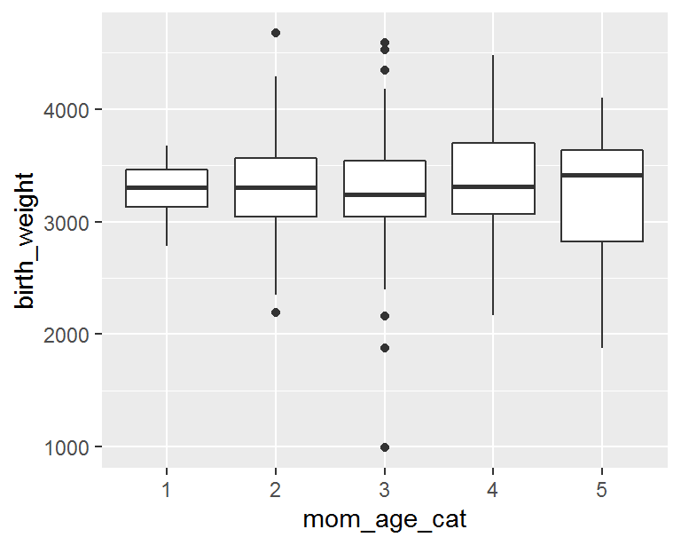

```
##
## Call:
## lm(formula = birth_weight ~ mom_age_cat + mom_edu_length + child_sex +
##     parity_cat + mom_weight + mom_height + gestational_age_weeks +
##     smoke_high_t2, data = bw_data)
##
## Residuals:
##      Min       1Q   Median       3Q      Max
## -1233.94  -237.56    -8.03   209.08  1347.87
##
## Coefficients:
##                           Estimate Std. Error t value Pr(>|t|)
## (Intercept)              -5413.522    675.735  -8.011 1.22e-14 ***
## mom_age_cat2                97.062    119.801   0.810  0.41831
## mom_age_cat3               110.917    117.991   0.940  0.34776
## mom_age_cat4               163.719    121.468   1.348  0.17847
## mom_age_cat5                92.440    159.062   0.581  0.56146
## mom_edu_lengthLong          43.300     41.490   1.044  0.29728
## mom_edu_lengthShort        108.946     54.538   1.998  0.04643 *
## child_sex2                 -85.016     35.163  -2.418  0.01606 *
## parity_catSecond or more   113.075     36.759   3.076  0.00224 **
## mom_weight                   4.104      1.715   2.393  0.01717 *
## mom_height                   7.508      2.996   2.506  0.01260 *
## gestational_age_weeks      177.186     12.073  14.676  < 2e-16 ***
## smoke_high_t21            -247.077    114.358  -2.161  0.03132 *
## ---
## Signif. codes:  0 '***' 0.001 '**' 0.01 '*' 0.05 '.' 0.1 ' ' 1
##
## Residual standard error: 353.7 on 405 degrees of freedom
##   (39 observations deleted due to missingness)
## Multiple R-squared:  0.3829, Adjusted R-squared:  0.3646
## F-statistic: 20.94 on 12 and 405 DF,  p-value: < 2.2e-16
```

- In summary

AIC for mom age at delivery models

| continuous | categorical |
| --- | --- |
| 6103 | 6107 |

=> `mom_age` best coded as **continuous**

### 5.1.2 Mom weight

- Continuous

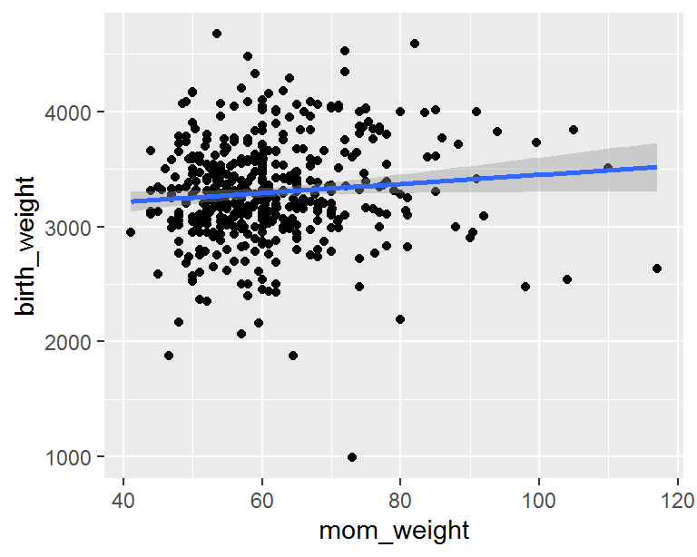

```
##
## Call:
## lm(formula = birth_weight ~ mom_age + mom_edu_length + child_sex +
##     parity_cat + mom_weight + mom_height + gestational_age_weeks +
##     smoke_high_t2, data = bw_data)
##
## Residuals:
##      Min       1Q   Median       3Q      Max
## -1295.64  -238.28   -12.25   206.54  1337.59
##
## Coefficients:
##                           Estimate Std. Error t value Pr(>|t|)
## (Intercept)              -5421.696    686.183  -7.901 2.59e-14 ***
## mom_age                      4.024      4.753   0.847  0.39771
## mom_edu_lengthLong          43.687     41.329   1.057  0.29112
## mom_edu_lengthShort        107.291     54.112   1.983  0.04806 *
## child_sex2                 -86.624     35.145  -2.465  0.01412 *
## parity_catSecond or more   119.153     36.860   3.233  0.00133 **
## mom_weight                   3.978      1.710   2.326  0.02052 *
## mom_height                   7.513      2.985   2.517  0.01222 *
## gestational_age_weeks      177.165     12.023  14.735  < 2e-16 ***
## smoke_high_t21            -255.056    113.690  -2.243  0.02540 *
## ---
## Signif. codes:  0 '***' 0.001 '**' 0.01 '*' 0.05 '.' 0.1 ' ' 1
##
## Residual standard error: 353.4 on 408 degrees of freedom
##   (39 observations deleted due to missingness)
## Multiple R-squared:  0.3794, Adjusted R-squared:  0.3657
## F-statistic: 27.72 on 9 and 408 DF,  p-value: < 2.2e-16
```

- Continuous, piecewise linear

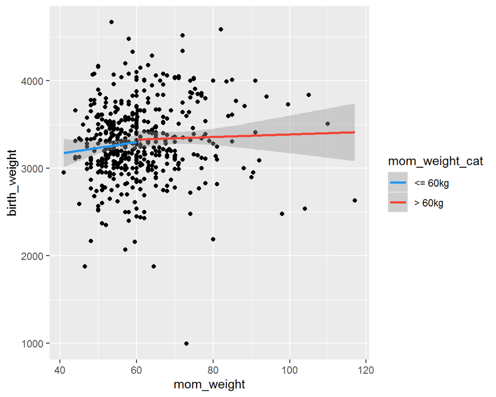

[output not shown]

- Categorical

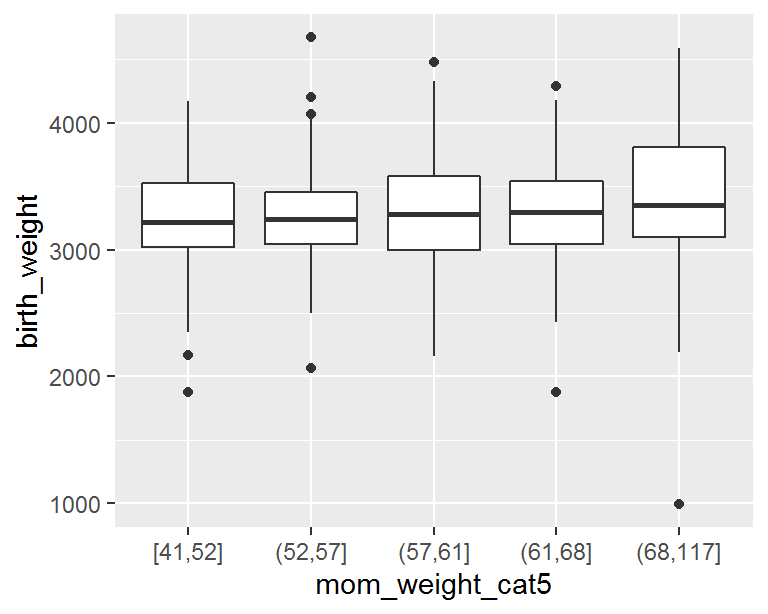

[output not shown]

- In summary

AIC for mom weight models

| continuous | categorical | two_slopes |
| --- | --- | --- |
| 6103 | 6107 | 6105 |

=> `mom_weight` best coded as **continuous**

### 5.1.3 Mom height

- Continuous

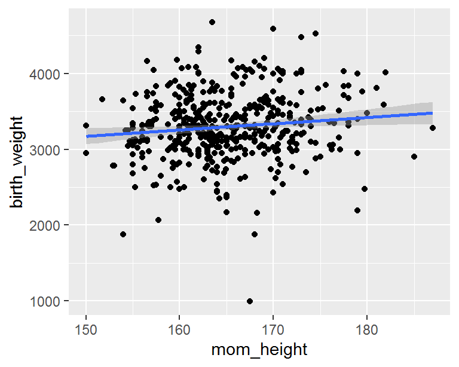

```
##
## Call:
## lm(formula = birth_weight ~ mom_age + mom_edu_length + child_sex +
##     parity_cat + mom_weight + mom_height + gestational_age_weeks +
##     smoke_high_t2, data = bw_data)
##
## Residuals:
##      Min       1Q   Median       3Q      Max
## -1295.64  -238.28   -12.25   206.54  1337.59
##
## Coefficients:
##                           Estimate Std. Error t value Pr(>|t|)
## (Intercept)              -5421.696    686.183  -7.901 2.59e-14 ***
## mom_age                      4.024      4.753   0.847  0.39771
## mom_edu_lengthLong          43.687     41.329   1.057  0.29112
## mom_edu_lengthShort        107.291     54.112   1.983  0.04806 *
## child_sex2                 -86.624     35.145  -2.465  0.01412 *
## parity_catSecond or more   119.153     36.860   3.233  0.00133 **
## mom_weight                   3.978      1.710   2.326  0.02052 *
## mom_height                   7.513      2.985   2.517  0.01222 *
## gestational_age_weeks      177.165     12.023  14.735  < 2e-16 ***
## smoke_high_t21            -255.056    113.690  -2.243  0.02540 *
## ---
## Signif. codes:  0 '***' 0.001 '**' 0.01 '*' 0.05 '.' 0.1 ' ' 1
##
## Residual standard error: 353.4 on 408 degrees of freedom
##   (39 observations deleted due to missingness)
## Multiple R-squared:  0.3794, Adjusted R-squared:  0.3657
## F-statistic: 27.72 on 9 and 408 DF,  p-value: < 2.2e-16
```

- Categorical

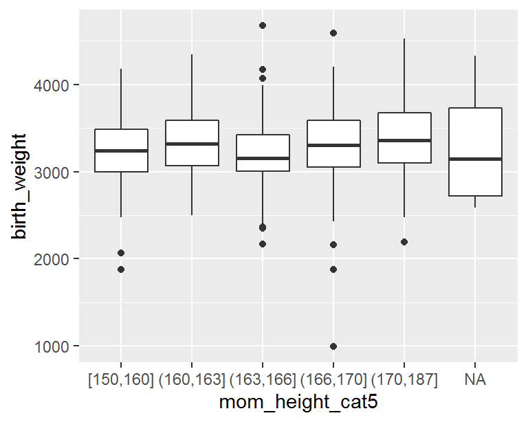

```
##
## Call:
## lm(formula = birth_weight ~ mom_age + mom_edu_length + child_sex +
##     parity_cat + mom_weight + mom_height_cat5 + gestational_age_weeks +
##     smoke_high_t2, data = bw_data)
##
## Residuals:
##      Min       1Q   Median       3Q      Max
## -1269.83  -237.11   -14.72   215.98  1370.15
##
## Coefficients:
##                           Estimate Std. Error t value Pr(>|t|)
## (Intercept)              -4326.150    536.125  -8.069 8.12e-15 ***
## mom_age                      5.141      4.750   1.082  0.27982
## mom_edu_lengthLong          45.281     41.291   1.097  0.27346
## mom_edu_lengthShort        107.971     54.098   1.996  0.04662 *
## child_sex2                 -84.854     35.207  -2.410  0.01639 *
## parity_catSecond or more   119.159     36.921   3.227  0.00135 **
## mom_weight                   4.182      1.695   2.467  0.01405 *
## mom_height_cat5(160,163]   110.001     54.073   2.034  0.04257 *
## mom_height_cat5(163,166]    51.236     55.305   0.926  0.35478
## mom_height_cat5(166,170]   147.905     53.197   2.780  0.00568 **
## mom_height_cat5(170,187]   149.288     58.090   2.570  0.01053 *
## gestational_age_weeks      177.254     12.041  14.721  < 2e-16 ***
## smoke_high_t21            -247.471    114.115  -2.169  0.03069 *
## ---
## Signif. codes:  0 '***' 0.001 '**' 0.01 '*' 0.05 '.' 0.1 ' ' 1
##
## Residual standard error: 352.8 on 405 degrees of freedom
##   (39 observations deleted due to missingness)
## Multiple R-squared:  0.3863, Adjusted R-squared:  0.3681
## F-statistic: 21.24 on 12 and 405 DF,  p-value: < 2.2e-16
```

- In summary

AIC for mom height models

| continuous | categorical |
| --- | --- |
| 6103 | 6105 |

=> `mom_height` best coded as **continuous**

### 5.1.4 BMI

- Continuous

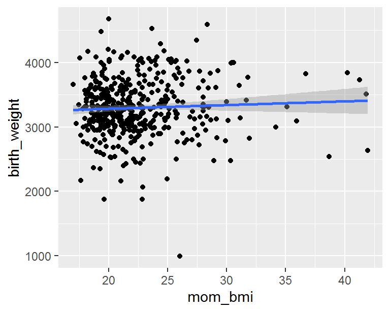

```
##
## Call:
## lm(formula = birth_weight ~ mom_age + mom_edu_length + child_sex +
##     parity_cat + mom_bmi + gestational_age_weeks + smoke_high_t2,
##     data = bw_data)
##
## Residuals:
##      Min       1Q   Median       3Q      Max
## -1373.24  -237.77   -23.79   220.51  1323.57
##
## Coefficients:
##                           Estimate Std. Error t value Pr(>|t|)
## (Intercept)              -4108.989    543.618  -7.559  2.7e-13 ***
## mom_age                      4.164      4.832   0.862  0.38926
## mom_edu_lengthLong          51.045     41.962   1.216  0.22451
## mom_edu_lengthShort        116.742     54.954   2.124  0.03424 *
## child_sex2                 -85.179     35.711  -2.385  0.01752 *
## parity_catSecond or more   119.783     37.457   3.198  0.00149 **
## mom_bmi                      9.418      4.660   2.021  0.04395 *
## gestational_age_weeks      175.875     12.207  14.408  < 2e-16 ***
## smoke_high_t21            -237.853    115.438  -2.060  0.03999 *
## ---
## Signif. codes:  0 '***' 0.001 '**' 0.01 '*' 0.05 '.' 0.1 ' ' 1
##
## Residual standard error: 359.1 on 409 degrees of freedom
##   (39 observations deleted due to missingness)
## Multiple R-squared:  0.3576, Adjusted R-squared:  0.345
## F-statistic: 28.46 on 8 and 409 DF,  p-value: < 2.2e-16
```

- Categorical

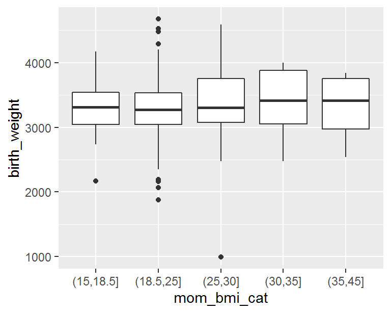

```
##
## Call:
## lm(formula = birth_weight ~ mom_age + mom_edu_length + child_sex +
##     parity_cat + mom_bmi_cat + gestational_age_weeks + smoke_high_t2,
##     data = bw_data)
##
## Residuals:
##      Min       1Q   Median       3Q      Max
## -1353.64  -228.58   -25.52   219.74  1313.50
##
## Coefficients:
##                           Estimate Std. Error t value Pr(>|t|)
## (Intercept)              -3919.400    532.087  -7.366 9.89e-13 ***
## mom_age                      4.003      4.850   0.825  0.40958
## mom_edu_lengthLong          48.202     42.069   1.146  0.25256
## mom_edu_lengthShort        117.164     55.255   2.120  0.03458 *
## child_sex2                 -87.552     36.062  -2.428  0.01562 *
## parity_catSecond or more   119.701     37.629   3.181  0.00158 **
## mom_bmi_cat(18.5,25]        23.703     72.764   0.326  0.74477
## mom_bmi_cat(25,30]          78.960     84.502   0.934  0.35064
## mom_bmi_cat(30,35]         206.046    135.444   1.521  0.12897
## mom_bmi_cat(35,45]         151.037    148.717   1.016  0.31043
## gestational_age_weeks      175.687     12.283  14.303  < 2e-16 ***
## smoke_high_t21            -232.013    116.181  -1.997  0.04649 *
## ---
## Signif. codes:  0 '***' 0.001 '**' 0.01 '*' 0.05 '.' 0.1 ' ' 1
##
## Residual standard error: 360.3 on 406 degrees of freedom
##   (39 observations deleted due to missingness)
## Multiple R-squared:  0.358,  Adjusted R-squared:  0.3406
## F-statistic: 20.58 on 11 and 406 DF,  p-value: < 2.2e-16
```

- In summary

AIC for BMI models

| continuous | categorical |
| --- | --- |
| 6116 | 6122 |

=> `mom_bmi` best coded as **continuous**

### 5.1.5 Mom weight + height VS BMI

Here we compare weight + height models VS BMI.

- Weight + Height

```
##
## Call:
## lm(formula = birth_weight ~ mom_age + mom_edu_length + child_sex +
##     parity_cat + mom_weight + mom_height + gestational_age_weeks +
##     smoke_high_t2, data = bw_data)
##
## Residuals:
##      Min       1Q   Median       3Q      Max
## -1295.64  -238.28   -12.25   206.54  1337.59
##
## Coefficients:
##                           Estimate Std. Error t value Pr(>|t|)
## (Intercept)              -5421.696    686.183  -7.901 2.59e-14 ***
## mom_age                      4.024      4.753   0.847  0.39771
## mom_edu_lengthLong          43.687     41.329   1.057  0.29112
## mom_edu_lengthShort        107.291     54.112   1.983  0.04806 *
## child_sex2                 -86.624     35.145  -2.465  0.01412 *
## parity_catSecond or more   119.153     36.860   3.233  0.00133 **
## mom_weight                   3.978      1.710   2.326  0.02052 *
## mom_height                   7.513      2.985   2.517  0.01222 *
## gestational_age_weeks      177.165     12.023  14.735  < 2e-16 ***
## smoke_high_t21            -255.056    113.690  -2.243  0.02540 *
## ---
## Signif. codes:  0 '***' 0.001 '**' 0.01 '*' 0.05 '.' 0.1 ' ' 1
##
## Residual standard error: 353.4 on 408 degrees of freedom
##   (39 observations deleted due to missingness)
## Multiple R-squared:  0.3794, Adjusted R-squared:  0.3657
## F-statistic: 27.72 on 9 and 408 DF,  p-value: < 2.2e-16
```

- BMI

```
##
## Call:
## lm(formula = birth_weight ~ mom_age + mom_edu_length + child_sex +
##     parity_cat + mom_bmi + gestational_age_weeks + smoke_high_t2,
##     data = bw_data)
##
## Residuals:
##      Min       1Q   Median       3Q      Max
## -1373.24  -237.77   -23.79   220.51  1323.57
##
## Coefficients:
##                           Estimate Std. Error t value Pr(>|t|)
## (Intercept)              -4108.989    543.618  -7.559  2.7e-13 ***
## mom_age                      4.164      4.832   0.862  0.38926
## mom_edu_lengthLong          51.045     41.962   1.216  0.22451
## mom_edu_lengthShort        116.742     54.954   2.124  0.03424 *
## child_sex2                 -85.179     35.711  -2.385  0.01752 *
## parity_catSecond or more   119.783     37.457   3.198  0.00149 **
## mom_bmi                      9.418      4.660   2.021  0.04395 *
## gestational_age_weeks      175.875     12.207  14.408  < 2e-16 ***
## smoke_high_t21            -237.853    115.438  -2.060  0.03999 *
## ---
## Signif. codes:  0 '***' 0.001 '**' 0.01 '*' 0.05 '.' 0.1 ' ' 1
##
## Residual standard error: 359.1 on 409 degrees of freedom
##   (39 observations deleted due to missingness)
## Multiple R-squared:  0.3576, Adjusted R-squared:  0.345
## F-statistic: 28.46 on 8 and 409 DF,  p-value: < 2.2e-16
```

- In summary

| height_weight | bmi |
| --- | --- |
| 6103 | 6116 |

=> model with **mom weight and height** better than model with mom BMI

### 5.1.6 Gestational age at delivery

Here we compare three different ways to model gestational age at delivery as a continuous variable: linear, age + age^2 and age^2 + age^3, and categorical.

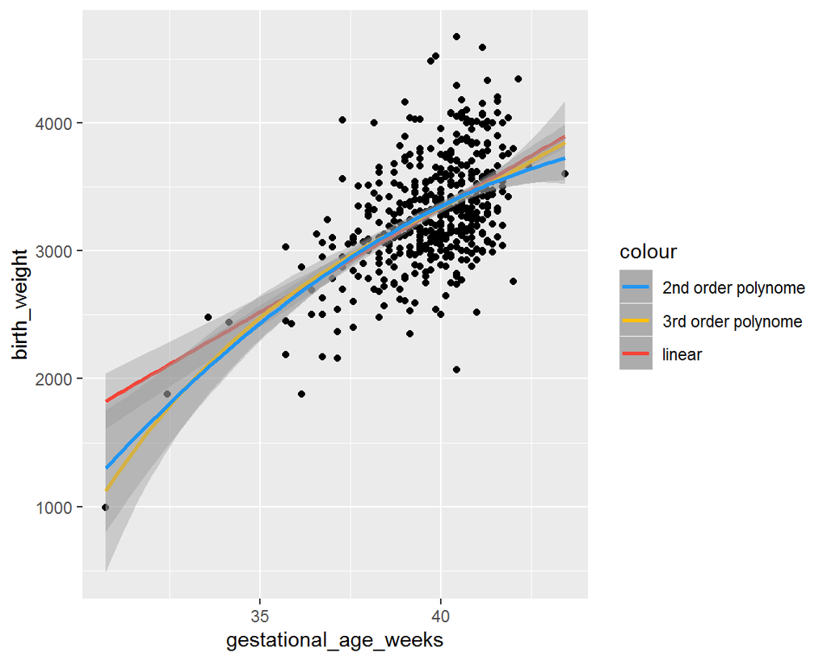

- Linear

```
##
## Call:
## lm(formula = birth_weight ~ mom_age + mom_edu_length + child_sex +
##     parity_cat + mom_weight + mom_height + gestational_age_weeks +
##     smoke_high_t2, data = bw_data)
##
## Residuals:
##      Min       1Q   Median       3Q      Max
## -1295.64  -238.28   -12.25   206.54  1337.59
##
## Coefficients:
##                           Estimate Std. Error t value Pr(>|t|)
## (Intercept)              -5421.696    686.183  -7.901 2.59e-14 ***
## mom_age                      4.024      4.753   0.847  0.39771
## mom_edu_lengthLong          43.687     41.329   1.057  0.29112
## mom_edu_lengthShort        107.291     54.112   1.983  0.04806 *
## child_sex2                 -86.624     35.145  -2.465  0.01412 *
## parity_catSecond or more   119.153     36.860   3.233  0.00133 **
## mom_weight                   3.978      1.710   2.326  0.02052 *
## mom_height                   7.513      2.985   2.517  0.01222 *
## gestational_age_weeks      177.165     12.023  14.735  < 2e-16 ***
## smoke_high_t21            -255.056    113.690  -2.243  0.02540 *
## ---
## Signif. codes:  0 '***' 0.001 '**' 0.01 '*' 0.05 '.' 0.1 ' ' 1
##
## Residual standard error: 353.4 on 408 degrees of freedom
##   (39 observations deleted due to missingness)
## Multiple R-squared:  0.3794, Adjusted R-squared:  0.3657
## F-statistic: 27.72 on 9 and 408 DF,  p-value: < 2.2e-16
```

- Age + Age^2

```
##
## Call:
## lm(formula = birth_weight ~ mom_age + mom_edu_length + child_sex +
##     parity_cat + mom_weight + mom_height + gestational_age_weeks +
##     I(gestational_age_weeks^2) + smoke_high_t2, data = bw_data)
##
## Residuals:
##      Min       1Q   Median       3Q      Max
## -1305.54  -233.43    -8.36   209.70  1343.82
##
## Coefficients:
##                              Estimate Std. Error t value Pr(>|t|)
## (Intercept)                -20475.103   5745.732  -3.564 0.000409 ***
## mom_age                         5.070      4.736   1.071 0.284998
## mom_edu_lengthLong             43.484     41.031   1.060 0.289869
## mom_edu_lengthShort           102.048     53.758   1.898 0.058363 .
## child_sex2                    -86.059     34.892  -2.466 0.014058 *
## parity_catSecond or more      114.283     36.640   3.119 0.001943 **
## mom_weight                      4.188      1.700   2.464 0.014160 *
## mom_height                      7.870      2.966   2.653 0.008286 **
## gestational_age_weeks         954.038    294.675   3.238 0.001304 **
## I(gestational_age_weeks^2)    -10.069      3.816  -2.639 0.008646 **
## smoke_high_t21               -259.816    112.882  -2.302 0.021859 *
## ---
## Signif. codes:  0 '***' 0.001 '**' 0.01 '*' 0.05 '.' 0.1 ' ' 1
##
## Residual standard error: 350.9 on 407 degrees of freedom
##   (39 observations deleted due to missingness)
## Multiple R-squared:  0.3899, Adjusted R-squared:  0.3749
## F-statistic: 26.01 on 10 and 407 DF,  p-value: < 2.2e-16
```

- Age^2 + Age^3

```
##
## Call:
## lm(formula = birth_weight ~ mom_age + mom_edu_length + child_sex +
##     parity_cat + mom_weight + mom_height + I(gestational_age_weeks^2) +
##     I(gestational_age_weeks^3) + smoke_high_t2, data = bw_data)
##
## Residuals:
##      Min       1Q   Median       3Q      Max
## -1308.01  -234.32    -7.29   211.05  1343.37
##
## Coefficients:
##                              Estimate Std. Error t value Pr(>|t|)
## (Intercept)                -8.584e+03  2.155e+03  -3.983 8.06e-05 ***
## mom_age                     5.118e+00  4.740e+00   1.080  0.28090
## mom_edu_lengthLong          4.450e+01  4.105e+01   1.084  0.27903
## mom_edu_lengthShort         1.030e+02  5.377e+01   1.916  0.05610 .
## child_sex2                 -8.589e+01  3.491e+01  -2.460  0.01429 *
## parity_catSecond or more    1.137e+02  3.667e+01   3.102  0.00206 **
## mom_weight                  4.188e+00  1.701e+00   2.463  0.01420 *
## mom_height                  7.867e+00  2.968e+00   2.651  0.00835 **
## I(gestational_age_weeks^2)  1.534e+01  4.115e+00   3.729  0.00022 ***
## I(gestational_age_weeks^3) -2.248e-01  7.075e-02  -3.178  0.00160 **
## smoke_high_t21             -2.603e+02  1.129e+02  -2.305  0.02168 *
## ---
## Signif. codes:  0 '***' 0.001 '**' 0.01 '*' 0.05 '.' 0.1 ' ' 1
##
## Residual standard error: 351 on 407 degrees of freedom
##   (39 observations deleted due to missingness)
## Multiple R-squared:  0.3893, Adjusted R-squared:  0.3743
## F-statistic: 25.94 on 10 and 407 DF,  p-value: < 2.2e-16
```

- Categorical

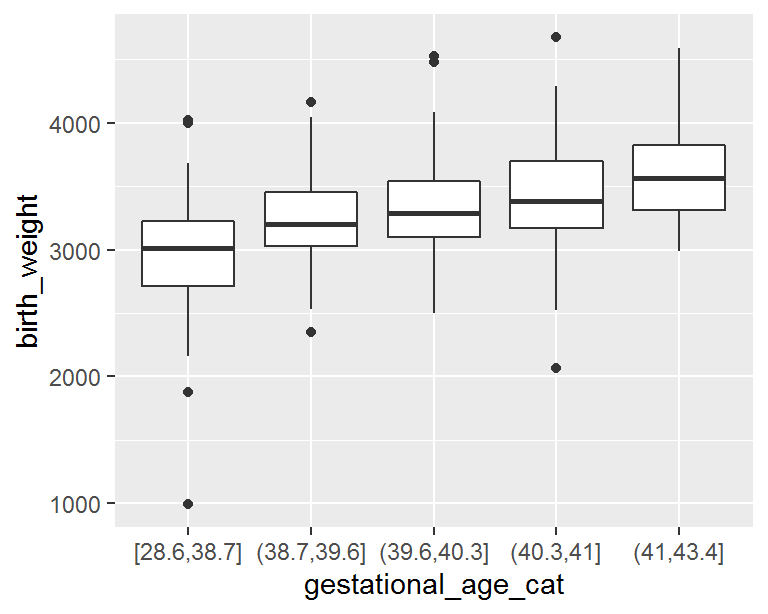

```
##
## Call:
## lm(formula = birth_weight ~ mom_age + mom_edu_length + child_sex +
##     parity_cat + mom_weight + mom_height + gestational_age_cat +
##     smoke_high_t2, data = bw_data)
##
## Residuals:
##     Min      1Q  Median      3Q     Max
## -2021.3  -241.4     1.9   223.3  1302.8
##
## Coefficients:
##                                Estimate Std. Error t value Pr(>|t|)
## (Intercept)                    1390.039    525.164   2.647 0.008441 **
## mom_age                           1.247      5.152   0.242 0.808846
## mom_edu_lengthLong               65.262     44.955   1.452 0.147351
## mom_edu_lengthShort             133.226     58.384   2.282 0.023013 *
## child_sex2                      -68.990     37.894  -1.821 0.069400 .
## parity_catSecond or more        133.612     39.898   3.349 0.000887 ***
## mom_weight                        2.960      1.844   1.605 0.109308
## mom_height                        7.384      3.219   2.294 0.022322 *
## gestational_age_cat(38.7,39.6]  321.913     59.317   5.427 9.89e-08 ***
## gestational_age_cat(39.6,40.3]  409.586     58.206   7.037 8.45e-12 ***
## gestational_age_cat(40.3,41]    510.352     56.470   9.038  < 2e-16 ***
## gestational_age_cat(41,43.4]    660.062     63.389  10.413  < 2e-16 ***
## smoke_high_t21                 -212.636    122.688  -1.733 0.083833 .
## ---
## Signif. codes:  0 '***' 0.001 '**' 0.01 '*' 0.05 '.' 0.1 ' ' 1
##
## Residual standard error: 380.9 on 405 degrees of freedom
##   (39 observations deleted due to missingness)
## Multiple R-squared:  0.2844, Adjusted R-squared:  0.2631
## F-statistic: 13.41 on 12 and 405 DF,  p-value: < 2.2e-16
```

- In summary

AIC for gestational age models

| continuous | age_age2 | age2_age3 | categorical |
| --- | --- | --- | --- |
| 6103 | 6098 | 6099 | 6169 |

=> `gestational_age` best coded as **age + age^2**

## 5.2 Categorical variables

### 5.2.1 Maternal education

Here we compare several `mom_education` classifications:

Classification 1

- 1 Primaire
- 2 College
- 3 BEP
- 4 CAP
- 5 Lycee
- 6 Bac +2
- 7 Bac +3-4
- 8 >=Bac +5

Classification 2

- 1 Primaire/College
- 2 BEP/CAP/Lycee
- 3 Bac +2
- 4 Bac +3-4
- 5 Bac +5

Classification 3

- 1 Primaire/College/BEP/CAP/Lycee/Bac +2
- 2 Bac +3-4
- 3 Bac +5

Classification 4

- 1 Primaire/College/BEP/CAP/Lycee
- 2 Bac +2-3-4
- 3 Bac +5

Classification 5

- Bac or less
- More than bac

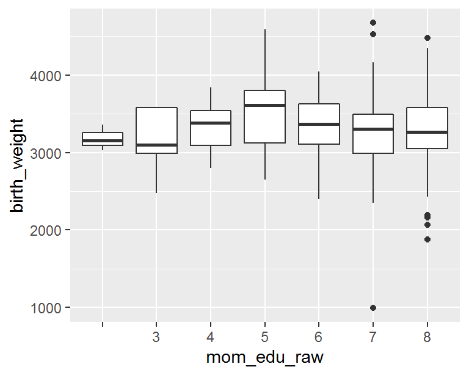

- Classification 1
  - 1 Primaire
  - 2 College
  - 3 BEP
  - 4 CAP
  - 5 Lycee
  - 6 Bac +2
  - 7 Bac +3-4
  - 8 >=Bac +5

```
##
## Call:
## lm(formula = birth_weight ~ mom_age + mom_edu_raw + child_sex +
##     parity_cat + mom_weight + mom_height + gestational_age_weeks +
##     I(gestational_age_weeks^2) + smoke_high_t2, data = bw_data)
##
## Residuals:
##      Min       1Q   Median       3Q      Max
## -1304.64  -230.24    -6.64   217.25  1345.62
##
## Coefficients:
##                              Estimate Std. Error t value Pr(>|t|)
## (Intercept)                -20702.126   5732.379  -3.611 0.000343 ***
## mom_age                         5.304      4.727   1.122 0.262511
## mom_edu_raw3                  -63.378    305.702  -0.207 0.835864
## mom_edu_raw4                  135.484    280.907   0.482 0.629848
## mom_edu_raw5                  319.082    274.183   1.164 0.245209
## mom_edu_raw6                  103.443    254.958   0.406 0.685158
## mom_edu_raw7                   25.233    252.421   0.100 0.920424
## mom_edu_raw8                   67.542    251.460   0.269 0.788374
## child_sex2                    -88.066     34.867  -2.526 0.011926 *
## parity_catSecond or more      112.781     36.527   3.088 0.002156 **
## mom_weight                      4.066      1.702   2.388 0.017383 *
## mom_height                      8.565      2.995   2.860 0.004461 **
## gestational_age_weeks         958.992    293.603   3.266 0.001182 **
## I(gestational_age_weeks^2)    -10.136      3.802  -2.666 0.007981 **
## smoke_high_t21               -279.935    115.694  -2.420 0.015977 *
## ---
## Signif. codes:  0 '***' 0.001 '**' 0.01 '*' 0.05 '.' 0.1 ' ' 1
##
## Residual standard error: 349.9 on 405 degrees of freedom
##   (37 observations deleted due to missingness)
## Multiple R-squared:  0.3964, Adjusted R-squared:  0.3755
## F-statistic:    19 on 14 and 405 DF,  p-value: < 2.2e-16
```

- Classification 2
  - 1 Primaire/College
  - 2 BEP/CAP/Lycee
  - 3 Bac +2
  - 4 Bac +3-4
  - 5 Bac +5

```
##
## Call:
## lm(formula = birth_weight ~ mom_age + mom_edu + child_sex + parity_cat +
##     mom_weight + mom_height + gestational_age_weeks + I(gestational_age_weeks^2) +
##     smoke_high_t2, data = bw_data)
##
## Residuals:
##      Min       1Q   Median       3Q      Max
## -1306.57  -229.94    -7.41   207.84  1344.13
##
## Coefficients:
##                              Estimate Std. Error t value Pr(>|t|)
## (Intercept)                -20443.444   5748.012  -3.557  0.00042 ***
## mom_age                         5.199      4.740   1.097  0.27336
## mom_eduBac +2                  36.218     55.138   0.657  0.51164
## mom_eduBac +3-4               -42.766     41.054  -1.042  0.29816
## mom_eduBEP/CAP/Lycee          113.924     81.262   1.402  0.16170
## child_sex2                    -87.087     34.925  -2.494  0.01305 *
## parity_catSecond or more      113.061     36.681   3.082  0.00219 **
## mom_weight                      4.085      1.705   2.396  0.01703 *
## mom_height                      8.128      2.983   2.725  0.00671 **
## gestational_age_weeks         952.444    294.783   3.231  0.00133 **
## I(gestational_age_weeks^2)    -10.046      3.817  -2.632  0.00882 **
## smoke_high_t21               -276.484    114.617  -2.412  0.01630 *
## ---
## Signif. codes:  0 '***' 0.001 '**' 0.01 '*' 0.05 '.' 0.1 ' ' 1
##
## Residual standard error: 351 on 406 degrees of freedom
##   (39 observations deleted due to missingness)
## Multiple R-squared:  0.3909, Adjusted R-squared:  0.3744
## F-statistic: 23.69 on 11 and 406 DF,  p-value: < 2.2e-16
```

- Classification 3
  - 1 Primaire/College/BEP/CAP/Lycee/Bac +2
  - 2 Bac +3-4
  - 3 Bac +5

```
##
## Call:
## lm(formula = birth_weight ~ mom_age + mom_edu_length + child_sex +
##     parity_cat + mom_weight + mom_height + gestational_age_weeks +
##     I(gestational_age_weeks^2) + smoke_high_t2, data = bw_data)
##
## Residuals:
##      Min       1Q   Median       3Q      Max
## -1305.54  -233.43    -8.36   209.70  1343.82
##
## Coefficients:
##                              Estimate Std. Error t value Pr(>|t|)
## (Intercept)                -20475.103   5745.732  -3.564 0.000409 ***
## mom_age                         5.070      4.736   1.071 0.284998
## mom_edu_lengthLong             43.484     41.031   1.060 0.289869
## mom_edu_lengthShort           102.048     53.758   1.898 0.058363 .
## child_sex2                    -86.059     34.892  -2.466 0.014058 *
## parity_catSecond or more      114.283     36.640   3.119 0.001943 **
## mom_weight                      4.188      1.700   2.464 0.014160 *
## mom_height                      7.870      2.966   2.653 0.008286 **
## gestational_age_weeks         954.038    294.675   3.238 0.001304 **
## I(gestational_age_weeks^2)    -10.069      3.816  -2.639 0.008646 **
## smoke_high_t21               -259.816    112.882  -2.302 0.021859 *
## ---
## Signif. codes:  0 '***' 0.001 '**' 0.01 '*' 0.05 '.' 0.1 ' ' 1
##
## Residual standard error: 350.9 on 407 degrees of freedom
##   (39 observations deleted due to missingness)
## Multiple R-squared:  0.3899, Adjusted R-squared:  0.3749
## F-statistic: 26.01 on 10 and 407 DF,  p-value: < 2.2e-16
```

- Classification 4
  - 1 Primaire/College/BEP/CAP/Lycee
  - 2 Bac +2-3-4
  - 3 Bac +5

```
##
## Call:
## lm(formula = birth_weight ~ mom_age + mom_edu_length2 + child_sex +
##     parity_cat + mom_weight + mom_height + gestational_age_weeks +
##     I(gestational_age_weeks^2) + smoke_high_t2, data = bw_data)
##
## Residuals:
##      Min       1Q   Median       3Q      Max
## -1307.13  -229.67    -8.34   210.82  1322.32
##
## Coefficients:
##                              Estimate Std. Error t value Pr(>|t|)
## (Intercept)                -20742.980   5749.453  -3.608 0.000347 ***
## mom_age                         5.103      4.743   1.076 0.282688
## mom_edu_length2Long            18.010     36.484   0.494 0.621817
## mom_edu_length2Short          131.861     81.806   1.612 0.107764
## child_sex2                    -91.251     34.811  -2.621 0.009087 **
## parity_catSecond or more      111.921     36.703   3.049 0.002443 **
## mom_weight                      4.226      1.703   2.482 0.013481 *
## mom_height                      8.311      2.982   2.787 0.005571 **
## gestational_age_weeks         964.638    294.896   3.271 0.001162 **
## I(gestational_age_weeks^2)    -10.195      3.819  -2.670 0.007900 **
## smoke_high_t21               -285.637    114.505  -2.495 0.013008 *
## ---
## Signif. codes:  0 '***' 0.001 '**' 0.01 '*' 0.05 '.' 0.1 ' ' 1
##
## Residual standard error: 351.3 on 407 degrees of freedom
##   (39 observations deleted due to missingness)
## Multiple R-squared:  0.3884, Adjusted R-squared:  0.3733
## F-statistic: 25.84 on 10 and 407 DF,  p-value: < 2.2e-16
```

- Classification 5
  - Bac or less
  - More than bac

```
##
## Call:
## lm(formula = birth_weight ~ mom_age + mom_edu_length3 + child_sex +
##     parity_cat + mom_weight + mom_height + gestational_age_weeks +
##     I(gestational_age_weeks^2) + smoke_high_t2, data = bw_data)
##
## Residuals:
##      Min       1Q   Median       3Q      Max
## -1301.65  -230.33    -5.94   205.31  1312.18
##
## Coefficients:
##                                Estimate Std. Error t value Pr(>|t|)
## (Intercept)                  -20581.440   5745.589  -3.582 0.000382 ***
## mom_age                           5.262      4.728   1.113 0.266433
## mom_edu_length3More than Bac   -122.335     79.424  -1.540 0.124266
## child_sex2                      -91.076     34.777  -2.619 0.009151 **
## parity_catSecond or more        110.462     36.550   3.022 0.002668 **
## mom_weight                        4.120      1.688   2.441 0.015068 *
## mom_height                        8.408      2.973   2.828 0.004911 **
## gestational_age_weeks           962.553    294.592   3.267 0.001177 **
## I(gestational_age_weeks^2)      -10.170      3.815  -2.666 0.007991 **
## smoke_high_t21                 -285.629    114.399  -2.497 0.012926 *
## ---
## Signif. codes:  0 '***' 0.001 '**' 0.01 '*' 0.05 '.' 0.1 ' ' 1
##
## Residual standard error: 351 on 408 degrees of freedom
##   (39 observations deleted due to missingness)
## Multiple R-squared:  0.388,  Adjusted R-squared:  0.3745
## F-statistic: 28.74 on 9 and 408 DF,  p-value: < 2.2e-16
```

- In summary

AIC for mom education model

| c1 | c2 | c3 | c4 | c5 |
| --- | --- | --- | --- | --- |
| 6129 | 6100 | 6098 | 6099 | 6098 |

- `mom_edu` best coded as classification 3 or 5
  - 1 Primaire/College/BEP/CAP/Lycee/Bac +2
  - 2 Bac +3-4
  - 3 Bac +5

  or
  - Bac or less
  - More than bac

### 5.2.2 Parity

Here we compare

- `parity`
  - First child
  - Second child
  - Third child
- `parity_cat`
  - First child
  - Second child or more

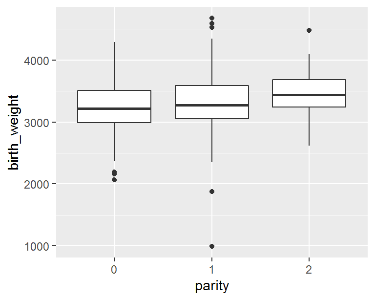

- Parity 1
  - First child
  - Second child
  - Third child

```
##
## Call:
## lm(formula = birth_weight ~ mom_age + mom_edu_length + child_sex +
##     parity + mom_weight + mom_height + gestational_age_weeks +
##     I(gestational_age_weeks^2) + smoke_high_t2, data = bw_data)
##
## Residuals:
##      Min       1Q   Median       3Q      Max
## -1300.23  -236.71    -1.46   201.74  1354.26
##
## Coefficients:
##                              Estimate Std. Error t value Pr(>|t|)
## (Intercept)                -20124.658   5753.149  -3.498 0.000521 ***
## mom_age                         4.325      4.783   0.904 0.366433
## mom_edu_lengthLong             45.667     41.069   1.112 0.266815
## mom_edu_lengthShort            98.611     53.835   1.832 0.067726 .
## child_sex2                    -84.392     34.916  -2.417 0.016090 *
## parity1                       103.009     38.044   2.708 0.007063 **
## parity2                       168.775     61.691   2.736 0.006496 **
## mom_weight                      4.324      1.704   2.538 0.011533 *
## mom_height                      7.457      2.990   2.494 0.013016 *
## gestational_age_weeks         940.722    294.851   3.191 0.001531 **
## I(gestational_age_weeks^2)     -9.904      3.818  -2.594 0.009829 **
## smoke_high_t21               -258.371    112.862  -2.289 0.022576 *
## ---
## Signif. codes:  0 '***' 0.001 '**' 0.01 '*' 0.05 '.' 0.1 ' ' 1
##
## Residual standard error: 350.8 on 406 degrees of freedom
##   (39 observations deleted due to missingness)
## Multiple R-squared:  0.3917, Adjusted R-squared:  0.3752
## F-statistic: 23.76 on 11 and 406 DF,  p-value: < 2.2e-16
```

- Parity 2
  - First child
  - Second child or more

```
##
## Call:
## lm(formula = birth_weight ~ mom_age + mom_edu_length + child_sex +
##     parity_cat + mom_weight + mom_height + gestational_age_weeks +
##     I(gestational_age_weeks^2) + smoke_high_t2, data = bw_data)
##
## Residuals:
##      Min       1Q   Median       3Q      Max
## -1305.54  -233.43    -8.36   209.70  1343.82
##
## Coefficients:
##                              Estimate Std. Error t value Pr(>|t|)
## (Intercept)                -20475.103   5745.732  -3.564 0.000409 ***
## mom_age                         5.070      4.736   1.071 0.284998
## mom_edu_lengthLong             43.484     41.031   1.060 0.289869
## mom_edu_lengthShort           102.048     53.758   1.898 0.058363 .
## child_sex2                    -86.059     34.892  -2.466 0.014058 *
## parity_catSecond or more      114.283     36.640   3.119 0.001943 **
## mom_weight                      4.188      1.700   2.464 0.014160 *
## mom_height                      7.870      2.966   2.653 0.008286 **
## gestational_age_weeks         954.038    294.675   3.238 0.001304 **
## I(gestational_age_weeks^2)    -10.069      3.816  -2.639 0.008646 **
## smoke_high_t21               -259.816    112.882  -2.302 0.021859 *
## ---
## Signif. codes:  0 '***' 0.001 '**' 0.01 '*' 0.05 '.' 0.1 ' ' 1
##
## Residual standard error: 350.9 on 407 degrees of freedom
##   (39 observations deleted due to missingness)
## Multiple R-squared:  0.3899, Adjusted R-squared:  0.3749
## F-statistic: 26.01 on 10 and 407 DF,  p-value: < 2.2e-16
```

- In summary

AIC for parity models

| parity | parity_cat |
| --- | --- |
| 6099 | 6098 |

- `parity` best coded as
  - First child
  - Second child or more

## 5.3 Tobacco

Because the Ns vary from one tobacco var to another, all tobacco models summarized in the following table were performed on the subset of women with all smoke data available.

N = 391

First columns represent the tobacco variable estimates, CI and p, last columns represent the model stats including that variable. Table is sorted in descending adjusted R squared.

Final column = number of missing in full data for that variable.

| smoke_var | estimate | conf.low | conf.high | p.value | adj.r.squared | AIC | df.residual | n_miss |
| --- | --- | --- | --- | --- | --- | --- | --- | --- |
| smoke_high_t2 | -472 | -820 | -124 | 0.008 | 0.389 | 5605 | 374 | 33 |
| smoke_n_cig_t2 | -201 | -374 | -27 | 0.023 | 0.386 | 5607 | 374 | 33 |
| smoke_high_t1 | -345 | -657 | -34 | 0.030 | 0.385 | 5607 | 374 | 36 |
| smoke_high_t1_t2 | -345 | -657 | -34 | 0.030 | 0.385 | 5607 | 374 | 39 |
| smoke_any_high | -237 | -522 | 47 | 0.102 | 0.382 | 5610 | 374 | 55 |
| smoke_t2 | -183 | -433 | 67 | 0.151 | 0.381 | 5610 | 374 | 30 |
| smoke_n_cig_t1 | -64 | -155 | 27 | 0.165 | 0.381 | 5610 | 374 | 36 |
| smoke_any | -137 | -360 | 86 | 0.227 | 0.380 | 5611 | 374 | 32 |
| smoke_n_cig_t3 | -106 | -287 | 74 | 0.247 | 0.380 | 5611 | 374 | 54 |
| smoke_high_t3 | -202 | -553 | 149 | 0.259 | 0.380 | 5611 | 374 | 54 |
| smoke_t3 | -170 | -485 | 146 | 0.291 | 0.379 | 5611 | 374 | 37 |
| smoke_t1 | -127 | -376 | 121 | 0.315 | 0.379 | 5611 | 374 | 35 |
| smoke_pre_detection | -4 | -31 | 23 | 0.792 | 0.378 | 5612 | 374 | 38 |

- In summary

Model with lowest AIC = `smoke_high_t2`

# 6 Summary

- `mom_age` best coded as **continuous**
- mom weight and height best coded as **mom_weight + mom_height** (rather than BMI) and both as **continuous**
- `gestational_age` best coded as **age + age^2**
- `mom_edu` best coded as
  - 1 Primaire/College/BEP/CAP/Lycee/Bac +2
  - 2 Bac +3-4
  - 3 Bac +5
- `parity` best coded as
  - First child
  - Second child or more
- `smoke` as smoked more than 1 cig/day at T2 VS not

# 7 References

Matthieu Rolland

2019-12-11